# EyalGreenbergCaseStudy6

Eyal Greenberg

June 19, 2016

#### Introduction

##### We have been given two sources of information, both from the World Bank Archive:

##### 1. The GDP file - includes the list of countries, their yearly GDP (in USD millions) and ranking, based on this GDP; and-

##### 2. The education file - includes various information, by country

##### The purpose of this project is to use these sources, combine them, and build an analysis to understand information that the education file has, but with the context of ranking of the country or group of countries.

```r
#### download and load the relevant packages for tidying the data
library(repmis)
library(RCurl)
library(tidyr)
library(dplyr)
```

```r
library(ggplot2)
#### Define names to the URLs
GDPsite <- "https://d396qusza40orc.cloudfront.net/getdata%2Fdata%2FGDP.csv"
EDUCsite <- "https://d396qusza40orc.cloudfront.net/getdata%2Fdata%2FEDSTATS_Country.csv"
#### Download the files to the working directory
download.file(GDPsite,"./GDPDataFile.csv")
download.file(EDUCsite,"./EDUCDataFile.csv")

#### load (="read") the files into R
GDPData <- read.csv("GDPDataFile.csv", sep = ",", skip = 4)
EDUCData <- read.csv("EDUCDataFile.csv", sep = ",", header = TRUE)

### We will start with cleaning the GDPData (EDUCData is ready for merge and we do not need to clean it)

#### delete the 3rd column, which is empty. In addition, delete the 5th through 9th columns, which are empty as well (column 5th has some irrelevant data in some rows)
GDPData2 <- GDPData[,-c(3, 6:10)]

#### Name the columns
names(GDPData2) <- c("CountryCode", "Ranking", "Economy", "GDPUSDMillions")

#### Rows 1 through 190 contain countries data. From row 191 and on, the data is irrelevant for our analysis since includes area (vs. countries) codes and some other parameters irrelevant for the analysis. We want our data to include only rows 1 through 190.
GDPData3 <- GDPData2[1:190, ]

#### GDPData3$GDPUSDMillionscolumn contains commas and therefore defined as factor. First we will delete the commas, and then convert the factors into numbers
GDPData3$GDPUSDMillions <- gsub(",", "", GDPData3$GDPUSDMillions)
GDPData3$GDPUSDMillions = as.numeric(GDPData3$GDPUSDMillions)

### Merge the two files
MergedData <- merge(x = GDPData3, y = EDUCData, by = "CountryCode", all = TRUE)
```

#### Question 1: Match the data based on the country shortcode. How many of the IDs match?

#### Answer:

##### First step: We will run the dim function in order to count the total rows in the merged file.

##### Second step: We will run the summary function, and count the NAs in column “Ranking” (originally in the GDP file)

##### Third step: We will deduct the total NAs in this column from the total numbers of rows. The remaining is the value we are looking for - the values that matched between the two files.

##### The total matched data is 235-45=190

```r
dim(MergedData)
```

```
## [1] 235  34
```

```r
summary(MergedData)
```

```
##   CountryCode     Ranking                   Economy    GDPUSDMillions
##  ABW    :  1   178    :  2   Afghanistan        :  1   Min.   :      40
##  ADO    :  1   1      :  1   Albania            :  1   1st Qu.:    7005
##  AFG    :  1   10     :  1   Algeria            :  1   Median :   27638
##  AGO    :  1   100    :  1   Angola             :  1   Mean   :  377652
##  ALB    :  1   101    :  1   Antigua and Barbuda:  1   3rd Qu.:  205289
##  ARE    :  1   (Other):184   (Other)            :185   Max.   :16244600
##  (Other):229   NA's   : 45   NA's               : 45   NA's   :45
##                   Long.Name                 Income.Group
##  American Samoa        :  1                       :24
##  Antigua and Barbuda   :  1   High income: nonOECD:37
##  Arab Republic of Egypt:  1   High income: OECD   :30
##  Argentine Republic    :  1   Low income          :40
##  Aruba                 :  1   Lower middle income :56
##  (Other)               :229   Upper middle income :47
##  NA's                  :  1   NA's                : 1
##                        Region   Lending.category    Other.groups
##  Europe & Central Asia    :57        :92                  :178
##  Sub-Saharan Africa       :47   Blend:16         Euro area: 16
##  Latin America & Caribbean:38   IBRD :63         HIPC     : 40
##  East Asia & Pacific      :36   IDA  :63         NA's     :  1
##                           :24   NA's : 1
##  (Other)                  :32
##  NA's                     : 1
##                Currency.Unit Latest.population.census
##                       : 24   2001   :46
##  Euro                 : 20   2000   :35
##  CFA franc            : 14          :26
##  U.S. dollar          : 13   2002   :21
##  East Caribbean dollar:  6   2006   :15
##  (Other)              :157   (Other):91
##  NA's                 :  1   NA's   : 1
##  Latest.household.survey
##            :112
##  MICS, 2006: 23
##  MICS, 2000:  8
##  DHS, 2005 :  7
##  DHS, 2007 :  6
##  (Other)   : 78
##  NA's      :  1
```

[output cut: 73 more lines]

```
##  Min.   :1995           Min.   :1975      Min.   :1990
##  1st Qu.:2002           1st Qu.:2007      1st Qu.:2000
##  Median :2004           Median :2008      Median :2000
##  Mean   :2003           Mean   :2007      Mean   :2001
##  3rd Qu.:2005           3rd Qu.:2008      3rd Qu.:2000
##  Max.   :2006           Max.   :2008      Max.   :2006
##  NA's   :140            NA's   :47        NA's   :83
##  X2.alpha.code   WB.2.code            Table.Name           Short.Name
##         : 26          : 25   Afghanistan   :  1   Afghanistan   :  1
##  AD     :  1   AD     :  1   Albania       :  1   Albania       :  1
##  AE     :  1   AE     :  1   Algeria       :  1   Algeria       :  1
##  AF     :  1   AF     :  1   American Samoa:  1   American Samoa:  1
##  AG     :  1   AG     :  1   Andorra       :  1   Andorra       :  1
##  (Other):203   (Other):204   (Other)       :229   (Other)       :229
##  NA's   :  2   NA's   :  2   NA's          :  1   NA's          :  1
```

#### Question 2: Sort the data frame in ascending order by GDP rank (so United States is last). What is the 13th country in the resulting data frame?

#### Answer:

#### First we will convert the Ranking from factor to numeric, and then we will use order command to sort. The 13th country in the sorted data is “St. Kitts and Nevis”"

```r
MergedData$Ranking = as.numeric(as.character(MergedData$Ranking))
MergedDataSorted <- MergedData[order(MergedData$Ranking, decreasing = TRUE),]
MergedDataSorted[13,]
```

```
##     CountryCode Ranking             Economy GDPUSDMillions
## 106         KNA     178 St. Kitts and Nevis            767
##               Long.Name        Income.Group                    Region
## 106 St. Kitts and Nevis Upper middle income Latin America & Caribbean
##     Lending.category Other.groups         Currency.Unit
## 106             IBRD              East Caribbean dollar
##     Latest.population.census Latest.household.survey Special.Notes
## 106                     2001
##     National.accounts.base.year National.accounts.reference.year
## 106                        1990                               NA
##     System.of.National.Accounts SNA.price.valuation
## 106                        1993                 VAB
##     Alternative.conversion.factor PPP.survey.year
## 106                                            NA
##     Balance.of.Payments.Manual.in.use External.debt.Reporting.status
## 106                              BPM5                    Preliminary
##     System.of.trade Government.Accounting.concept
## 106         General                  Consolidated
##     IMF.data.dissemination.standard
## 106                            GDDS
##     Source.of.most.recent.Income.and.expenditure.data
## 106
##     Vital.registration.complete Latest.agricultural.census
## 106
##     Latest.industrial.data Latest.trade.data Latest.water.withdrawal.data
## 106                     NA              2007                           NA
##     X2.alpha.code WB.2.code          Table.Name          Short.Name
## 106            KN        KN St. Kitts and Nevis St. Kitts and Nevis
```

#### Question 3: What are the average GDP rankings for the “High income: OECD” and “High income: nonOECD” groups?

#### Answer:

#### We will create a sub-list with the required cut and calculate the mean of the ranking of this list. The mean is 58.54717

```r
Question2Data <- subset(MergedDataSorted, MergedDataSorted$Income.Group %in% c("High income: OECD", "High income: nonOECD"))
mean(Question2Data$Ranking, na.rm = TRUE)
```

```
## [1] 58.54717
```

#### Question 4: Plot the GDP for all of the countries. Use ggplot2 to color your plot by Income Group

#### Answer:

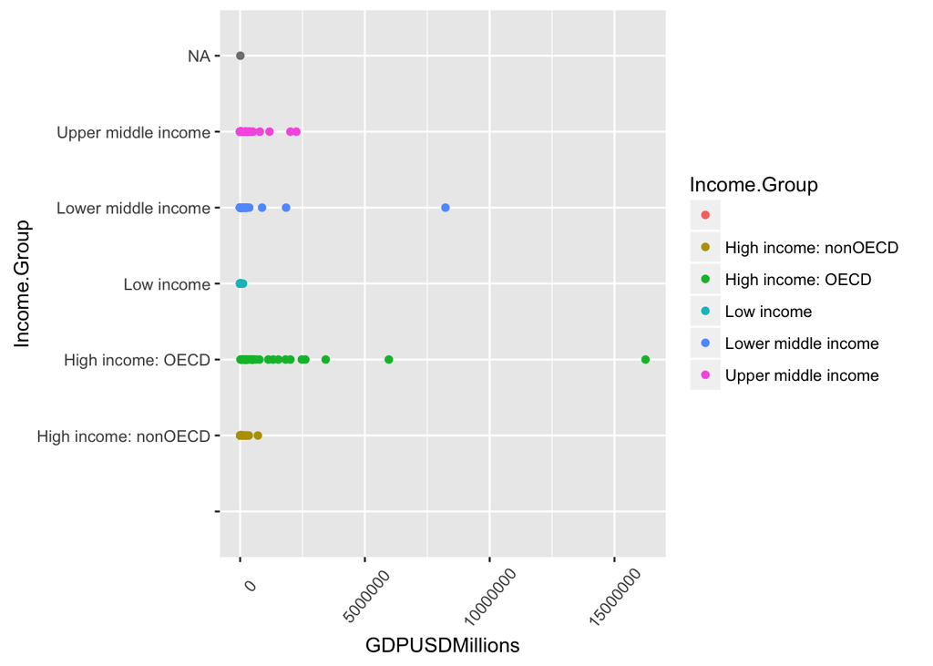

```r
ggplot(MergedDataSorted, aes(GDPUSDMillions, Income.Group, color = Income.Group)) + geom_point() + theme(axis.text.x=element_text(angle = 50, vjust = 0.5)) + scale_x_continuous(labels = function(n) {format(n,scientific = F)})
```

#### Question 5: Cut the GDP ranking into 5 separate quantile groups. Make a table versus Income.Group. How many countries are Lower middle income but among the 38 nations with highest GDP?

#### Answer:

#### First we will define the five groups, by GDP. Since we have 190 observations, each quantile is precisely 38 observations.

#### We will sum the Income group variable equal to “Lower middle income” in the first group (q1 group), and we can see that the answer is 5.

```r
q1 <- subset(MergedDataSorted, Ranking <=38 )
q2 <- subset(MergedDataSorted, Ranking > 38 & Ranking <= 76)
q3 <- subset(MergedDataSorted, Ranking > 76 & Ranking <= 114)
q4 <- subset(MergedDataSorted, Ranking > 114 & Ranking <= 152)
q5 <- subset(MergedDataSorted, Ranking > 152 & Ranking <= 190)
sum(q1$Income.Group == "Lower middle income")
```

```
## [1] 5
```

#### Summary and conclusion

##### 1. We have found that there are three countries with GDP significantly larger than the rest of the world - USA, China and Japan;

##### 2. We can see that USA and Japan are in the “High Income: OECD” group, while china is in the “Lower Middle Income” group;

##### 3. “Low Income” group contains countries with very low GDP, but “High Income Non OECD” group - as well. This is compared to “High Income OECD” and “Upper Middle Income” - these two groups have more variety of GDP in it, including countries with high GDP;

##### 4. Finally, we can see that out of 38 countries, the upper quantile in terms of GDP ranking, only 5 countries are in the “Lower Middle Income”.